# My Report

Sam

2026-05-01

## The Museum Project.

This project is dedicated to the Royal Ontario Museum. The dataset that I employed in this project is a spurious one which simulates a data taken from an actual museum. The code chunk below will load all the necessary packages that we will be using for the analysis.

```r
library(tidyverse)
library(kableExtra)
library(modelsummary)
```

## Data Integration.

The code below will load the data we need.

```r
df <- read.csv("C:\\Users\\cem-1\\Downloads\\museum_full_dataset.csv")
```

## Data Wrangling.

the $head$ command will show us the first 10 lines of dataset.After glimpsing the dataset, we observe that actually we do not need all variables in the dataset. So that, the columns $visit_id$ and $visitor_id$ will be removed,

```r
head(df, 10)
```

```
##    visit_id visitor_id exhibit_id time_spent_min rating visit_date age gender
## 1      VIS0     V03614         E7       49.61848      4 2025-11-23  28 Female
## 2      VIS0     V03614         E7       49.61848      4 2025-11-23  28 Female
## 3      VIS0     V03614         E7       49.61848      4 2025-11-23  28 Female
## 4      VIS0     V03614         E7       49.61848      4 2025-11-23  28 Female
## 5      VIS0     V03614         E7       49.61848      4 2025-11-23  28 Female
## 6      VIS1     V04771        E11       17.67138      5 2025-10-14  70   Male
## 7      VIS1     V04771        E11       17.67138      5 2025-10-14  70   Male
## 8      VIS1     V04771        E11       17.67138      5 2025-10-14  70   Male
## 9      VIS1     V04771        E11       17.67138      5 2025-10-14  70   Male
## 10     VIS1     V04771        E11       17.67138      5 2025-10-14  70   Male
##    country membership_type group_size    exhibit_name category interactive
## 1    India          Member          3 Medieval Europe  History           0
## 2    India          Member          3 Medieval Europe  History           0
## 3    India          Member          3 Medieval Europe  History           0
```

[output cut: 18 more lines]

```r
df <- df %>%
  select(-c(visit_id, visitor_id))
```

```r
df %>%
  summarise(across(everything(), ~ sum(is.na(.))))
```

```
##   exhibit_id time_spent_min rating visit_date   age gender country
## 1          0           8889  11943          0 17367      0       0
##   membership_type group_size exhibit_name category interactive transaction_id
## 1               0          0            0        0           0              0
##   ticket_type purchase_channel price
## 1           0                0   113
```

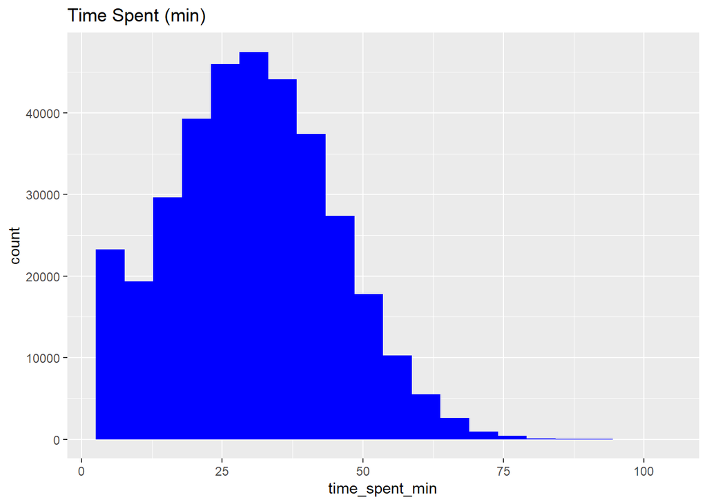

```r
ggplot(df, aes(x = time_spent_min)) +
  geom_histogram(bins = 20, fill = "blue") +
  ggtitle("Time Spent (min)")
```

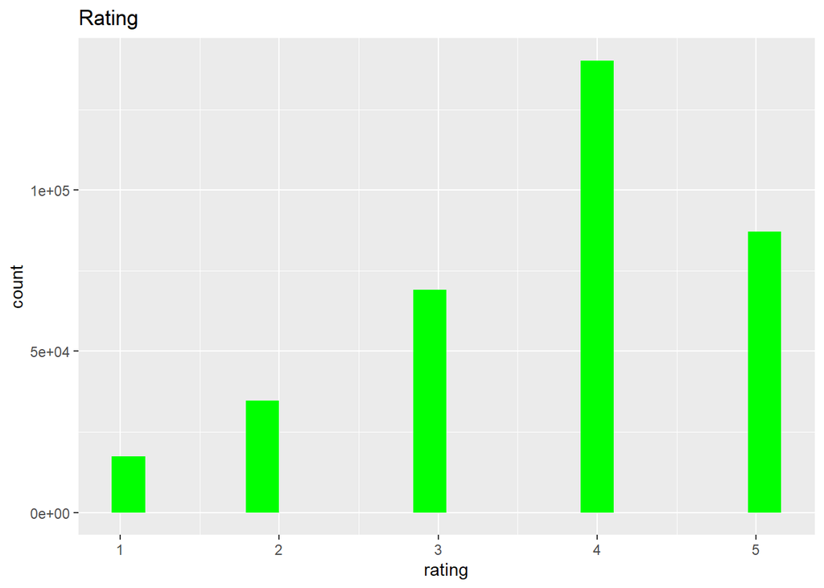

```r
ggplot(df, aes(x = rating)) +
  geom_histogram(bins = 20, fill = "green") +
  ggtitle("Rating")
```

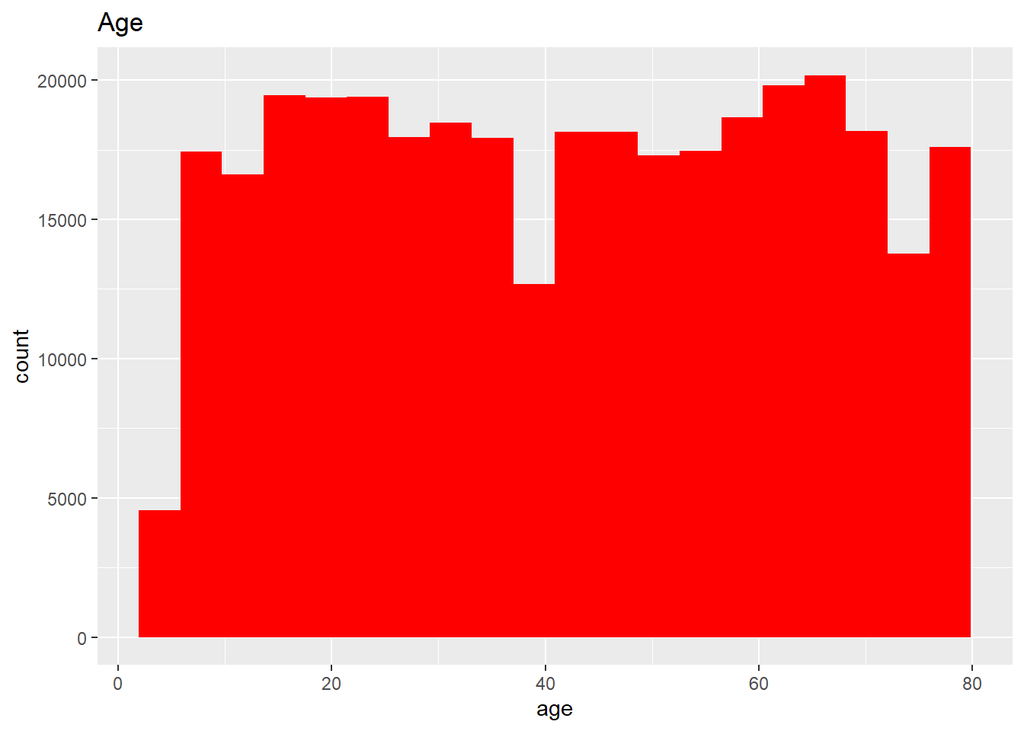

```r
ggplot(df, aes(x = age)) +
  geom_histogram(bins = 20, fill = "red") +
  ggtitle("Age")
```

```r
x <- mean(df$time_spent_min, na.rm = TRUE)
y <- median(df$age, na.rm = TRUE)
z <- mode_value <- names(sort(table(df$rating), decreasing = TRUE))[1]
mode_value
```

```
## [1] "4"
```

```r
df$time_spent_min[is.na(df$time_spent_min)] <- x
df$age[is.na(df$age)] <- y
df$rating[is.na(df$rating)] <- z
```

## Correlation Analysis

The data is now functional which means that now it is ready for the analytics. At this part, we will be doing some correlation analysis. Firstly I would like to examine a graph by age and gender in order to gain an insight on what gender and age group visits the museum the most.

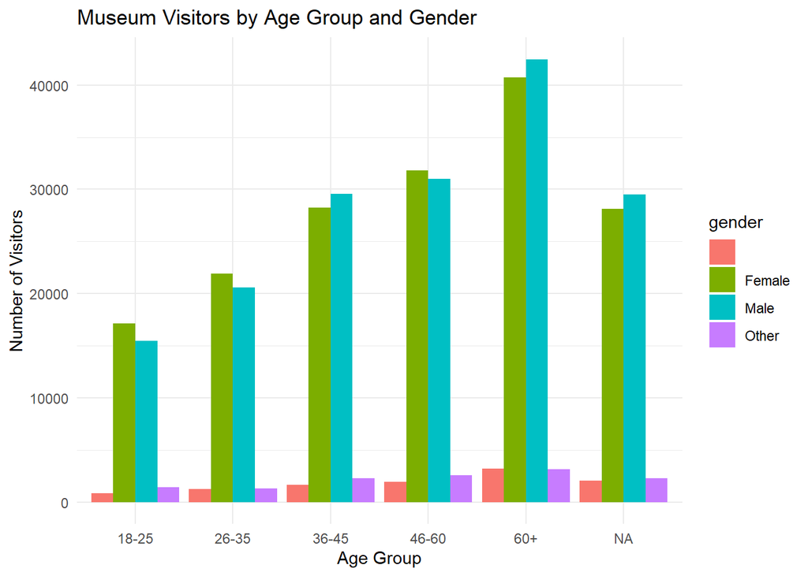

```r
summary_df <- df %>%
  mutate(age_group = cut(age,
                         breaks = c(18, 25, 35, 45, 60, Inf),
                         labels = c("18-25", "26-35", "36-45", "46-60", "60+"),
                         right = TRUE)) %>%
  count(age_group, gender)

ggplot(summary_df, aes(x = age_group, y = n, fill = gender)) +
  geom_bar(stat = "identity", position = "dodge") +
  labs(title = "Museum Visitors by Age Group and Gender",
       x = "Age Group",
       y = "Number of Visitors") +
  theme_minimal()
```

As we examine the graph, the very first observation is that the number of visitors by gender is roughly the same, however the insight that is noticable is that the young women prefer to visit museums more than the young man. On the other hand, this observation is reserved as the people get older. The elderly gentleman visits the museum more then the old ladies.

Next, we will be analyzing the most popular parts of the museum by taking a closer look at why some people spend more time.

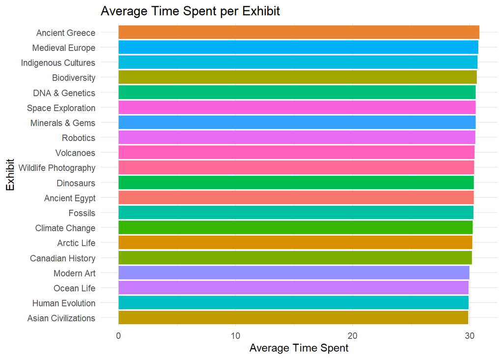

```r
summary_df <- df %>%
  group_by(exhibit_name) %>%
  summarise(avg_time = mean(time_spent_min, na.rm = TRUE),
            visits = n())

ggplot(summary_df, aes(x = reorder(exhibit_name, avg_time),
                       y = avg_time,
                       fill = exhibit_name)) +
  geom_col(show.legend = FALSE) +
  coord_flip() +
  labs(title = "Average Time Spent per Exhibit",
       x = "Exhibit",
       y = "Average Time Spent") +

  theme_minimal()
```

According to the bar chart above, visitors approximately spend the same amount of time accross all sections of the museum, which is $30 minutes$. Therefore, we conclude that people make a full museum tour once they visit the museum, they value each section equally, even if they do not they still allocate the same amount of time for each sections.

### Memberships.

Now we will investigate the popularity of membership types.

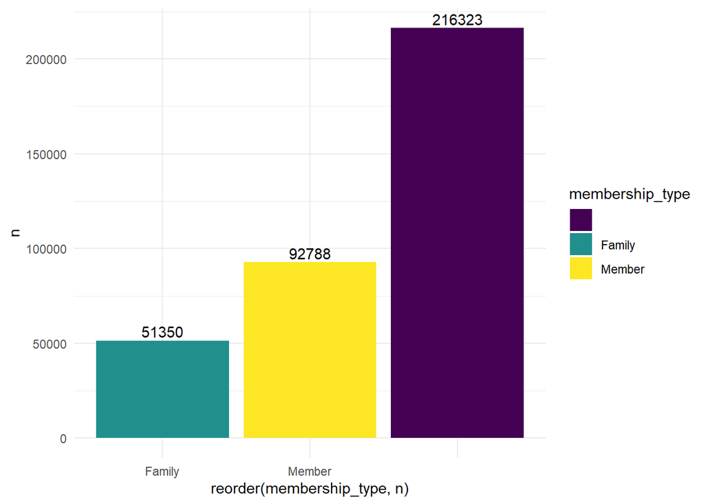

```r
membership_df <- df  %>%
  count(membership_type)

ggplot(membership_df,
       aes(x = reorder(membership_type, n),
           y = n,
           fill = membership_type)) +
  geom_col() +
  geom_text(aes(label = n), vjust = -0.3) +
  theme_minimal() +
  scale_fill_viridis_d()
```

In terms of the membership types, it is clear that the general admission category is the most popular by a large margin. Therefore, most likely most people do not bother to sign up for membership programs.

### Purchase Channel.

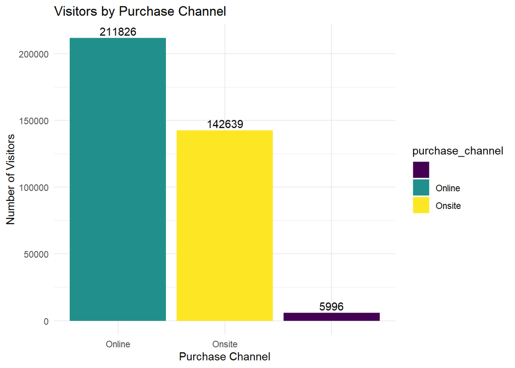

```r
channel_df <- df %>%
  count(purchase_channel)

ggplot(channel_df,
       aes(x = reorder(purchase_channel, -n),
           y = n,
           fill = purchase_channel)) +
  geom_col() +
  geom_text(aes(label = n), vjust = -0.3) +

  labs(title = "Visitors by Purchase Channel",
       x = "Purchase Channel",   # 👈 this fixes missing column name
       y = "Number of Visitors") +

  theme_minimal() +
  scale_fill_viridis_d()
```

### Interactivity by Visitors.

In this part, we will analyze if people prefer interactive or the static parts of the museum. We will create a chart that illustrates which sections spend more time.

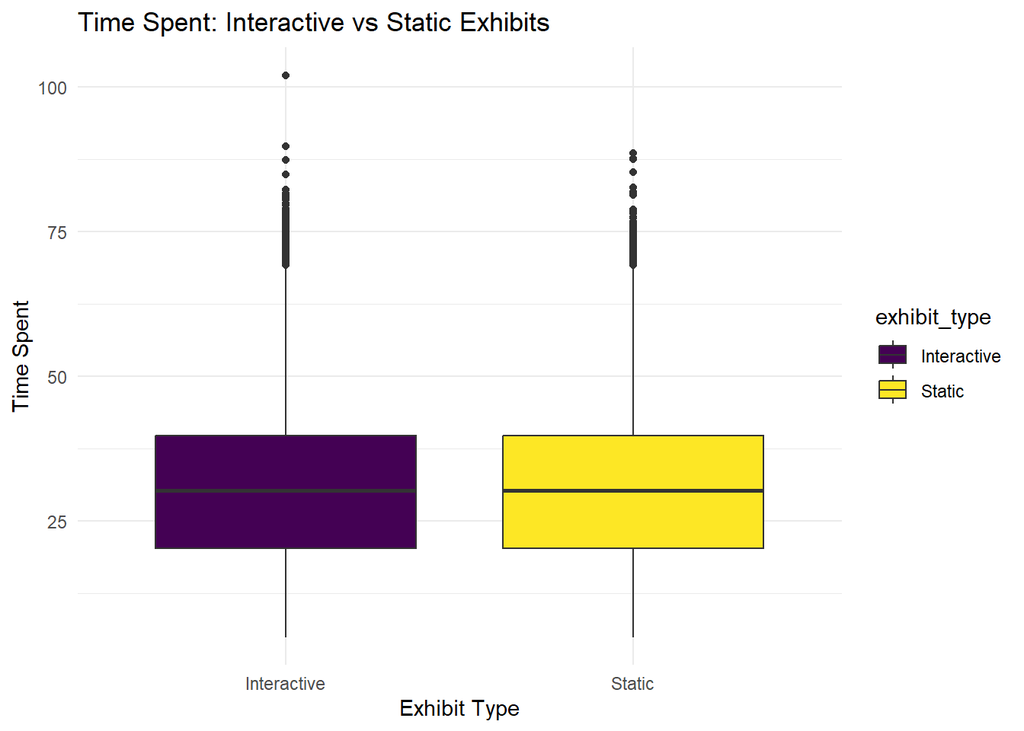

```r
df$exhibit_type <- ifelse(df$interactive == 1, "Interactive", "Static") # this code will convert the binary variable to string.

library(ggplot2)

ggplot(df, aes(x = exhibit_type, y = time_spent_min, fill = exhibit_type)) +
  geom_boxplot() +

  labs(title = "Time Spent: Interactive vs Static Exhibits",
       x = "Exhibit Type",
       y = "Time Spent") +

  theme_minimal() +
  scale_fill_viridis_d()
```

In total we have 162581 $Interactive$ and 197880 $Static$ exhibitions availabe in the museum. On average people spend the same time around these categories, however Interactive section has more outliers on how much time people spend. What this tells us that probably there are some $interactive$ parts in the museum that are fairly interesting.

## Rating

Now we will investigate which parts of the museum are highly rated by visitors.

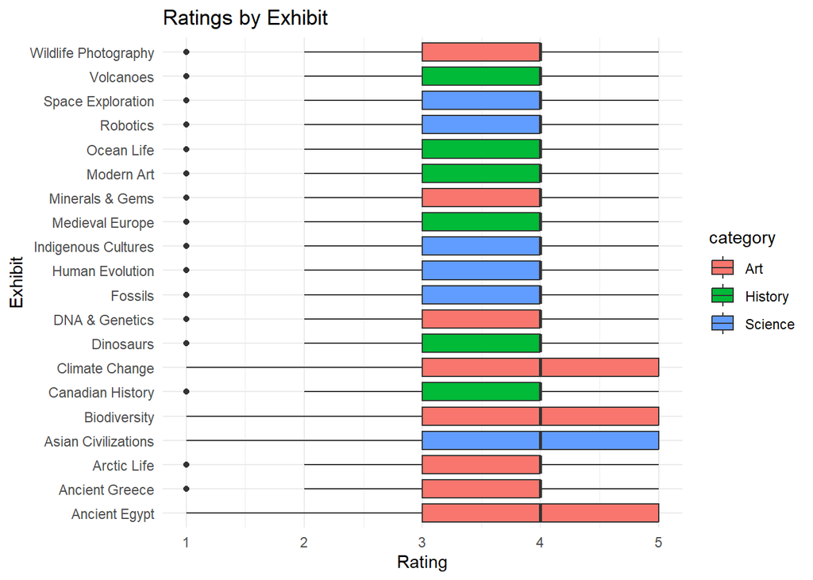

```r
df$rating <- as.numeric(df$rating)

df_clean <- df[!is.na(df$rating) &
               !is.na(df$exhibit_name) &
               !is.na(df$category), ]

ggplot(df_clean,
       aes(x = exhibit_name,
           y = rating,
           fill = category)) +
  geom_boxplot() +
  coord_flip() +

  labs(title = "Ratings by Exhibit",
       x = "Exhibit",
       y = "Rating") +

  theme_minimal()
```

### Museum visit dates.

We now will analyze the dats in which people visit the museum. What I intend to know is if people visit the museum more during weekdays, weekends and the holidays. The answer is most likely yes, but it has to be proven by data.

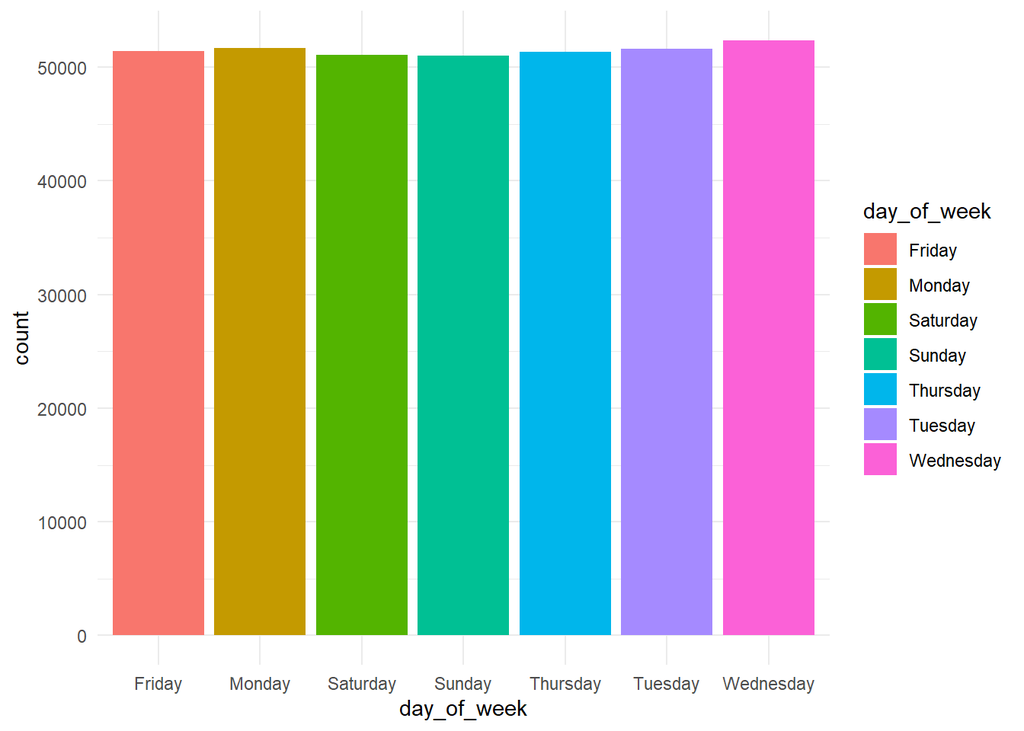

```r
df$visit_date <- as.Date(df$visit_date) # this code will convert the visit_Date column to date from character.

df$day_of_week <- weekdays(df$visit_date) # this code will convert the dates to days of the wekk.

ggplot(df, aes(x = day_of_week, fill = day_of_week)) +
  geom_bar() +
  theme_minimal()
```

The data actually proved my prediction to be wrong. Based on the bar chart above, people usually visit the museum almost equally all days of the week. $Wednesday$ is the most popular but only with a small margin. Most individuals are free on the weekend, however probably weekdays attract school trips, university research students etc.

# The Final Report.